# HW4

Панюшев Николай

17 апреля 2016 г

## Считывание и форматирование данных

Считаем таблицу и посмотрим, что там:

```r
setwd('~/R')
raw_data <- read.csv('cafedata.csv', header = T, sep = ",", dec = c("," , "."))
str(raw_data)
```

```
## 'data.frame':    48 obs. of  27 variables:
##  $ t                    : int  1 2 3 4 5 6 7 8 9 10 ...
##  $ Date                 : Factor w/ 48 levels "1/19/2010","1/20/2010",..: 1 2 3 4 5 6 7 8 9 12 ...
##  $ Day.Code             : int  2 3 4 5 1 2 3 4 5 1 ...
##  $ Day.of.Week          : Factor w/ 5 levels "Fri","Mon","Thu",..: 4 5 3 1 2 4 5 3 1 2 ...
##  $ Bread.Sand.Sold      : int  5 6 8 4 3 7 6 0 3 2 ...
##  $ Bread.Sand.Waste     : int  3 8 2 2 0 1 6 0 4 6 ...
##  $ Bread.Sand.Share     : num  0.625 0.429 0.8 0.667 1 ...
##  $ Wraps.Sold           : int  25 7 14 5 10 5 19 7 4 13 ...
##  $ Wraps.Waste          : int  5 17 0 7 0 3 3 0 9 3 ...
##  $ Wraps.Share          : num  0.833 0.292 1 0.417 1 ...
##  $ Muffins.Sold         : int  5 3 4 5 8 1 6 6 0 3 ...
##  $ Muffins.Waste        : int  1 5 0 0 0 0 0 1 4 0 ...
##  $ Muffins.Share        : num  0.833 0.375 1 1 1 ...
##  $ Cookies.Sold         : int  5 1 1 3 3 5 10 0 3 6 ...
##  $ Cookies.Waste        : int  3 6 0 1 0 0 0 0 2 0 ...
##  $ Cookies.Share        : num  0.625 0.143 1 0.75 1 ...
##  $ Fruit.Cup.Sold       : int  1 0 0 3 2 2 2 0 1 2 ...
##  $ Fruit.Cup.Waste      : int  4 3 3 0 0 0 0 0 1 0 ...
##  $ Fruit.Cup.Share      : num  0.2 0 0 1 1 1 1 NA 0.5 1 ...
##  $ Chips                : int  12 0 0 20 0 4 2 20 3 16 ...
##  $ Juices               : int  8 0 13 0 5 4 5 6 4 7 ...
##  $ Sodas                : int  20 13 23 13 13 33 15 27 12 19 ...
##  $ Coffees              : int  41 33 34 27 20 23 32 31 30 27 ...
##  $ Total.Soda.and.Coffee: int  61 46 57 40 33 56 47 58 42 46 ...
##  $ Sales.               : Factor w/ 48 levels "","101,76","102,68",..: 34 32 3 23 2 31 6 38 46 5 ...
##  $ Max.Daily.Temp.F     : int  36 34 39 40 36 26 34 33 20 37 ...
##  $ Total.Items.Wasted   : int  16 39 5 10 0 4 9 1 20 9 ...
```

Непорядок какой-то с переменными Date, Sales. - они как факторы указаны, пофиксим:

```r
raw_data$Sales <- as.character(raw_data$Sales.)
raw_data$Sales <- sub("," , ".", raw_data$Sales)
raw_data$Sales <- as.numeric(raw_data$Sales)
raw_data$Date <- as.Date(raw_data$Date, format = "%m/%d/%Y")
raw_data$Sales. <- NULL #Удалили исходную переменную Sales.
```

Переименуем все переменные .Sold - уберем этот хвостик

```r
library(data.table, quietly = T)
setnames(raw_data, c('Bread.Sand.Sold',
             'Wraps.Sold', 'Muffins.Sold',
            'Cookies.Sold', 'Fruit.Cup.Sold'),
            c('Bread', 'Wraps', 'Muffins', 'Cookies', 'Fruit.Cups'))
```

## Изгнание мультиколлинеарности

Сделаем функцию для отбора сильно коррелирующих значений:

```r
high_corr <- function(data_frame){
  correlations <- cor(data_frame[sapply(raw_data, is.numeric)],
                    use = "pairwise.complete.obs",
                    method = "pearson") # корреляции всех со всеми
  correlations <- as.data.frame(correlations)
  correlations[lower.tri(correlations, diag = T)] <- NA # выкинули главную диагональ
  var1 <- correlations[correlations > 0.75 | correlations  < (-0.75)]
  var1 <- var1[!is.na(var1)] # выделили только выдающиеся корреляции
  corr.names <- names(correlations)
  result <- matrix(ncol=3, dimnames = list(NULL, c('Var1', 'Var2', 'Correlation')))

  for (i in var1){
    tmp <- which(correlations == i, arr.ind = T, useNames = F)
    tmp <- as.vector(tmp)
    result <- rbind(c(corr.names[tmp], i), result)
    }
  return(result)
}
```

ОЙ-ОЙ! Кажется, я левелапнулся!

Посмотрим, что тут у нас:

```r
print(high_corr(raw_data))
```

```
##       Var1                    Var2                 Correlation
##  [1,] "Total.Soda.and.Coffee" "Sales"              "0.780394352096815"
##  [2,] "Wraps.Share"           "Total.Items.Wasted" "-0.788362233310987"
##  [3,] "Wraps.Waste"           "Total.Items.Wasted" "0.939373752167028"
##  [4,] "t"                     "Max.Daily.Temp.F"   "0.761524779602367"
##  [5,] "Fruit.Cup.Waste"       "Fruit.Cup.Share"    "-0.852618145770778"
##  [6,] "Cookies.Waste"         "Cookies.Share"      "-0.917292617995014"
##  [7,] "Muffins.Waste"         "Muffins.Share"      "-0.919045887858278"
##  [8,] "Wraps.Waste"           "Wraps.Share"        "-0.91253723143509"
##  [9,] "Bread.Sand.Waste"      "Bread.Sand.Share"   "-0.894733175990774"
## [10,] NA                      NA                   NA
```

Очевидно, что переменные .Share и .Waste будут сильно коррелировать, поэтому удалим все .Share

```r
raw_data[grepl(".Share", names(raw_data))] <- NULL
```

Еще коррелируют Wraps.waste и Total.Items.Wasted - удалим Total.Items.Wasted, она как-то косо посчитана.

```r
raw_data$Total.Items.Wasted <- NULL
raw_data$t <- NULL #удалим и ее, зачем она нам, если есть даты?
```

А теперь посмотрим, от продажи чего зависят общие продажи:

```r
library(stargazer, quietly = T)
fit1 <- lm(Sales ~ Total.Soda.and.Coffee, data = raw_data)
stargazer(fit1, type="html")
```

|  | *Dependent variable:* |
| --- | --- |
|  | Sales |
| Total.Soda.and.Coffee | 2.825*** |
|  | (0.337) |
| Constant | 3.931 |
|  | (17.737) |
| Observations | 47 |
| R<sup>2</sup> | 0.609 |
| Adjusted R<sup>2</sup> | 0.600 |
| Residual Std. Error | 28.741 (df = 45) |
| F Statistic | 70.094*** (df = 1; 45) |
| *Note:* | p<0.1; p<0.05; p<0.01 |

```r
#А теперь построим линейную модель от всех переменных
fit2 <- lm(Sales ~ . , data = raw_data)
stargazer(fit2, type="html")
```

|  | *Dependent variable:* |
| --- | --- |
|  | Sales |
| Date | -0.466 |
|  | (0.418) |
| Day.Code | -21.466** |
|  | (9.654) |
| Day.of.WeekMon | -43.690 |
|  | (30.735) |
| Day.of.WeekThu | 39.588** |
|  | (15.282) |
| Day.of.WeekTue | 5.353 |
|  | (18.530) |
| Day.of.WeekWed |  |
| Bread | -3.259 |
|  | (2.522) |
| Bread.Sand.Waste | -3.263 |
|  | (2.719) |
| Wraps | 0.800 |
|  | (1.015) |
| Wraps.Waste | 3.638 |
|  | (2.602) |
| Muffins | 2.595** |
|  | (1.020) |
| Muffins.Waste | 7.226* |
|  | (4.152) |
| Cookies | -0.725 |
|  | (1.567) |
| Cookies.Waste | 2.113 |
|  | (4.201) |
| Fruit.Cups | 7.124* |
|  | (3.844) |
| Fruit.Cup.Waste | -4.908 |
|  | (6.120) |
| Chips | 1.532** |
|  | (0.704) |
| Juices | -1.307 |
|  | (1.280) |
| Sodas | 1.751** |
|  | (0.813) |
| Coffees | 1.453** |
|  | (0.585) |
| Total.Soda.and.Coffee |  |
| Max.Daily.Temp.F | 0.127 |
|  | (0.462) |
| Constant | 6,920.386 |
|  | (6,088.469) |
| Observations | 47 |
| R<sup>2</sup> | 0.878 |
| Adjusted R<sup>2</sup> | 0.785 |
| Residual Std. Error | 21.082 (df = 26) |
| F Statistic | 9.396*** (df = 20; 26) |
| *Note:* | p<0.1; p<0.05; p<0.01 |

Да, по линейной модели видно, что продажи зависят на 60% от продажи кофе и газировки. Но присутствие переменной Total.Soda.and.Coffee сведет на нет вклад всех остальных факторов, поэтому мы ее удалим.

```r
raw_data$Total.Soda.and.Coffee <- NULL
```

## Факторный анализ

### Группировка переменных

Чтобы построить хорошую модель, посмотрим, какие признаки можно сгруппировать между собой.

Прогоним метод главных компонент, посмотрим на ординацию признаков, а потом скорректируем наши факторы.

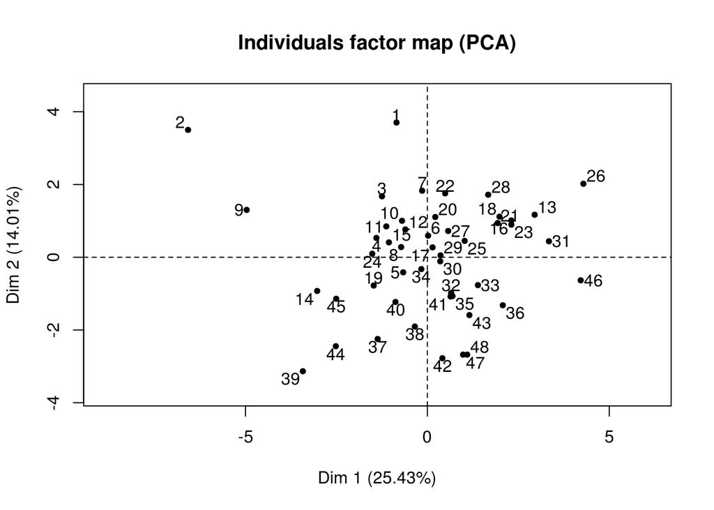

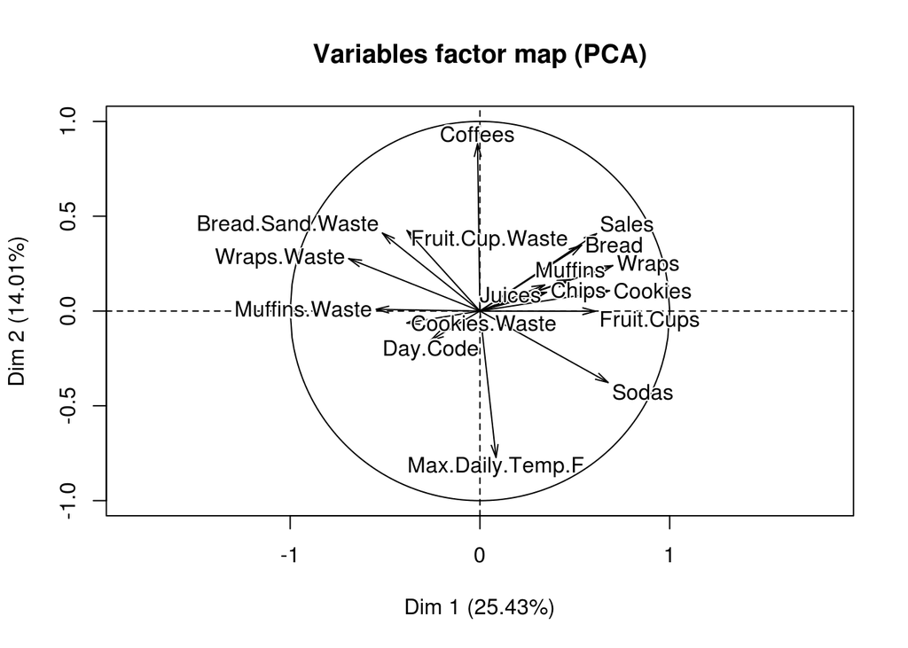

```r
library(FactoMineR, quietly = T)
numeric_data <-raw_data[sapply(raw_data, is.numeric)]
result <- PCA(numeric_data)
```

Что мы видим: 5 “пучков” векторов - это все переменные .Waste, Coffees, Остальные продукты, Sodas, Daily Temp. Причем продажи кофе отрицательно скоррелированы с температурой! А продажи газировки, наоборот! В принципе, логично.

Теперь сгруппируем переменные .Waste и сделаем переменную Other.Products и удалим старые переменные

```r
group_data <- numeric_data
group_data$Wastes <- rowSums(numeric_data[endsWith(names(numeric_data), ".Waste")])
group_data[endsWith(names(numeric_data), ".Waste")] <- NULL
group_data$Other.Products <- group_data$Bread + group_data$Wraps + group_data$Juices +
  group_data$Muffins + group_data$Chips
+ group_data$Fruit.Cups + group_data$Cookies
```

```
##  [1]  6  1  1  6  5  7 12  0  4  8  6  6 16  1  9 11  8 11  4 10  6 11 12
## [24]  4  8 16  7  8  8  8 11 11 10 NA  6 14  6  9  4  4  6  7  5  6  1 13
## [47] 12  7
```

```r
group_data$Bread = group_data$Wraps = group_data$Juices = group_data$Muffins = group_data$Chips = group_data$Fruit.Cups = group_data$Cookies <- NULL
```

И еще раз посмотрим на результат PCA:

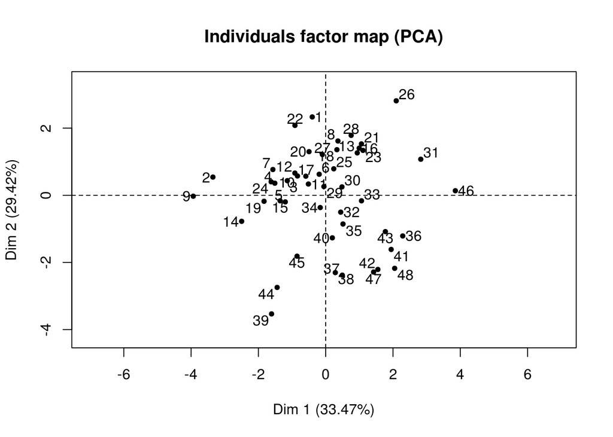

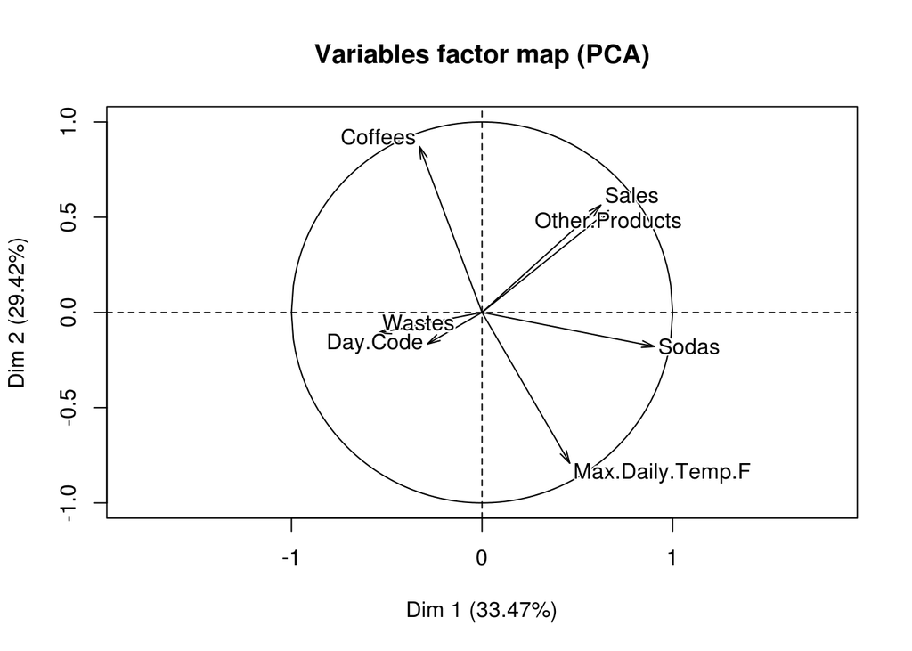

```r
result_2 <- PCA(group_data)
```

Красота, все очень логично выглядит! В жару никто кофе не пьет, пьют холодненькую газировку; количество выброшенного товара увеличивается, если продажи низкие; продажи зависят еще и от продажи других продуктов! Хотя, может, и наоборот, кофе вызывает жару, но не будем об этом..

### Регрессионная модель

```r
new_fit <-  lm(Coffees ~ Max.Daily.Temp.F, group_data)
stargazer(new_fit, type="html")
```

|  | *Dependent variable:* |
| --- | --- |
|  | Coffees |
| Max.Daily.Temp.F | -0.569*** |
|  | (0.077) |
| Constant | 45.313*** |
|  | (3.395) |
| Observations | 47 |
| R<sup>2</sup> | 0.550 |
| Adjusted R<sup>2</sup> | 0.540 |
| Residual Std. Error | 7.519 (df = 45) |
| F Statistic | 54.895*** (df = 1; 45) |
| *Note:* | p<0.1; p<0.05; p<0.01 |

Отлично! Регрессионная модель подтверждает наше предположение, хотя R^2 и всего около 0.5

## 3d график

Построим красивый график, чтобы все было наглядно! К сожалению, у меня не работает rgl - выдает ошибку - ‘next3d’ is not an exported object from ‘namespace:rgl’ Поэтому, ничего красивого не вышло(

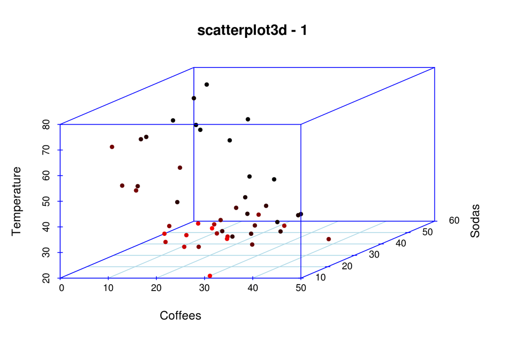

```r
library(ggplot2, ggrepel, quietly = T)
library(scatterplot3d, quietly = T)

Coffees <-  numeric_data$Coffees
Sodas <-  numeric_data$Sodas
Temperature <- numeric_data$Max.Daily.Temp.F

#scatter3d(Coffees, Sodas, Temperature)

library(scatterplot3d) # какой-то некрасивый совсем график

scatterplot3d(Coffees, Sodas, Temperature, highlight.3d=TRUE, col.axis="blue",
col.grid="lightblue", main="scatterplot3d - 1", pch=20)
```